# Personalized Map Art with OSM and R

## Getting more specific

Above, I used `getbb()` to set the boundary box for East Lansing, MI. However, we are not always interested in an entire city or an easily named area. In these cases we set our own boundary box. Here I am choosing coordinates that bound MSU’s campus, which I have taken from Google Maps.

```r
min_lon <- -84.493675; max_lon <- -84.462183
min_lat <- 42.711814; max_lat <- 42.735481
campus_bbx <- rbind(x=c(min_lon,max_lon),y=c(min_lat,max_lat))
colnames(campus_bbx) <- c("min","max")
```

```r
campus_sidewalks <- campus_bbx %>%
  opq() %>%
  add_osm_feature(key = "footway") %>%
  osmdata_sf()

campus_roads <- campus_bbx %>%
  opq() %>%
  add_osm_feature(key = "highway") %>%
  osmdata_sf()

campus_buildings <- campus_bbx %>%
  opq() %>%
  add_osm_feature(key = "buildings") %>%
  osmdata_sf()
```

```r
color_roads <- rgb(0.42,0.449,0.488)
```

Plotting roads and sidewalks of campus, using `coord_sf()` to cut off any roads that extend outside the map boundaries.

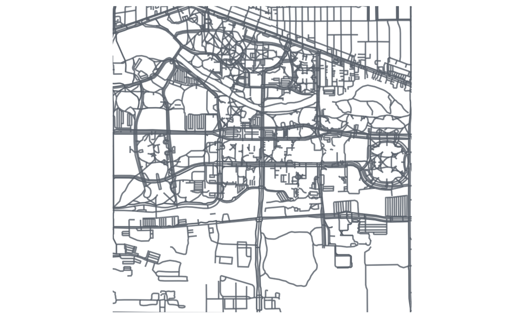

```r
ggplot() +
  geom_sf(data = campus_sidewalks$osm_lines,
          col = color_roads,
          size = 0.4,
          alpha = 0.65) +
  geom_sf(data = campus_roads$osm_lines,
          col = color_roads,
          size = 0.6,
          alpha = 0.8) +
  coord_sf(xlim = c(min_lon, max_lon),
           ylim = c(min_lat, max_lat),
           expand = FALSE) + #expand = FALSE will cut off any roads that extend outside you border
  theme(axis.line=element_blank(),
        axis.text.x=element_blank(),
        axis.text.y=element_blank(),
        axis.ticks=element_blank(),
        axis.title.x=element_blank(),
        axis.title.y=element_blank(),
        legend.position="none",
        panel.background=element_blank(),
        panel.border=element_blank(),
        panel.grid.major=element_blank(),
        panel.grid.minor=element_blank(),
        plot.background=element_rect(fill = NULL))
```

## Adding water with tigris

MSU’s campus features the Red Cedar River, so let’s see if we can get that on the map.

This code gets us county lines for the state of Michigan and crops to our boundary box with `st_crop()`. In such a small area this pretty much equates to no lines, but it does give us a background and a location to add water to later.

```r
counties_MI <- counties(state="MI",cb=T,class="sf",)
counties_MI <- st_crop(counties_MI,
                       xmin=min_lon,xmax=max_lon,
                       ymin=min_lat,ymax=max_lat)
```

```
although coordinates are longitude/latitude, st_intersection assumes that they are planar
attribute variables are assumed to be spatially constant throughout all geometries
```

A quick look at our non-existent county lines on the MSU campus.

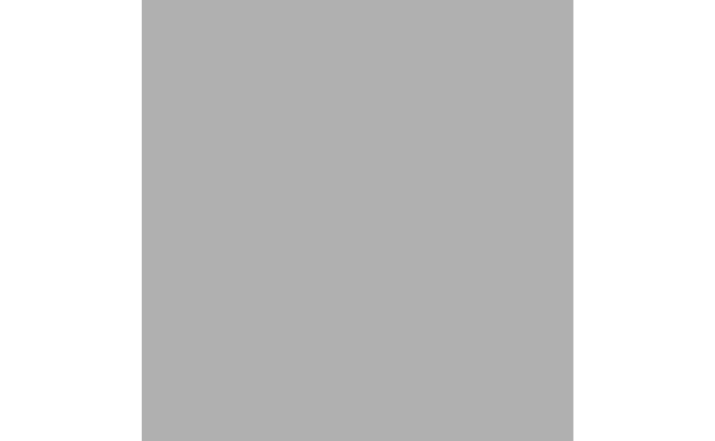

```r
ggplot() +
  geom_sf(data=counties_MI,fill="gray",lwd=0) +
  coord_sf(xlim = c(min(campus_bbx[1,]), max(campus_bbx[1,])),
         ylim = c(min(campus_bbx[2,]), max(campus_bbx[2,])),
         expand = FALSE) +
  theme(legend.position = F) +
  theme_void()
```

To get the water in our location, we need some custom code, which I thank Dr. Esteban Moro for including in his blog post [here](http://estebanmoro.org/post/2020-10-19-personal-art-map-with-r/).

```r
get_water <- function(county_GEOID){
  area_water("MI", county_GEOID, class = "sf")
}
water <- do.call(rbind,
                 lapply(counties_MI$COUNTYFP,get_water))
```

[output not shown]

```r
water <- st_crop(water,
                 xmin=min_lon,xmax=max_lon,
                 ymin=min_lat,ymax=max_lat)
```

```
although coordinates are longitude/latitude, st_intersection assumes that they are planar
attribute variables are assumed to be spatially constant throughout all geometries
```

If we take a look at the only water feature in our campus location, we can see the Red Cedar River.

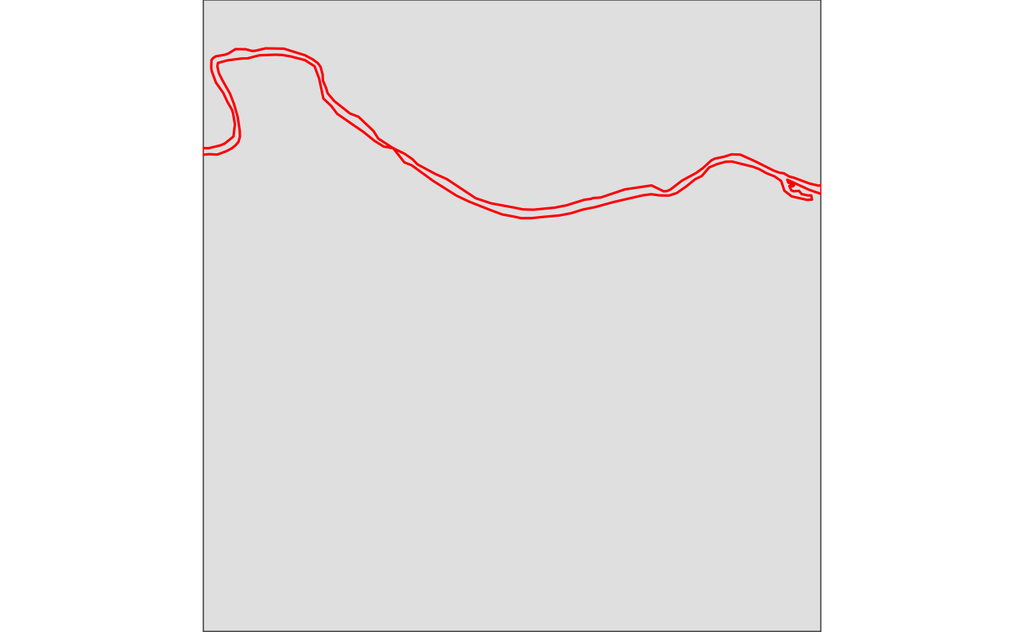

```r
ggplot() +
  geom_sf(data=counties_MI)+
  geom_sf(data=water,
          inherit.aes = F,
          col="red")+
  coord_sf(xlim = c(min(campus_bbx[1,]), max(campus_bbx[1,])),
         ylim = c(min(campus_bbx[2,]), max(campus_bbx[2,])),
         expand = FALSE)+
  theme(legend.position = F) + theme_void()
```

We can now use the water polygon we created to carve area out of our counties polygon, again with a custom function I took from Esteban Moro’s blog post.

```r
st_erase <- function(x, y) {
  st_difference(x, st_union(y))
}
counties_MI <- st_erase(counties_MI,water)
```

```
although coordinates are longitude/latitude, st_union assumes that they are planar
although coordinates are longitude/latitude, st_difference assumes that they are planar
attribute variables are assumed to be spatially constant throughout all geometries
```

We can now see the water feature carved out of our geographical background.

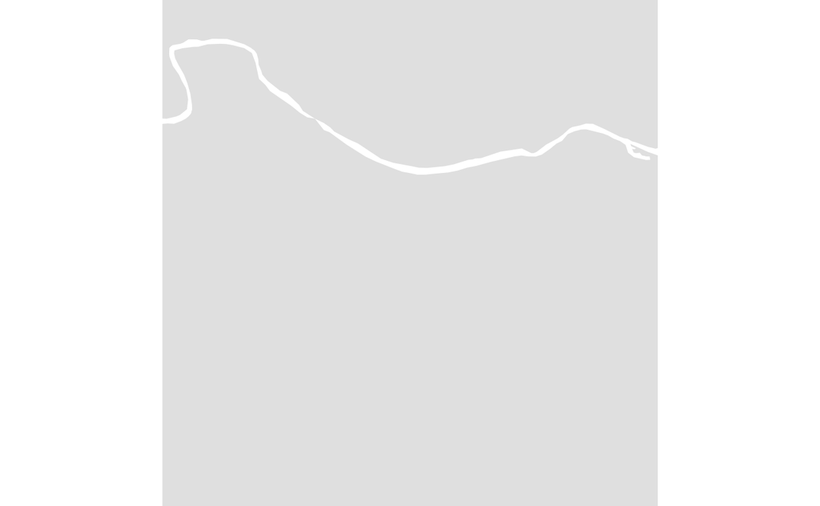

```r
ggplot() +
  geom_sf(data=counties_MI,
          lwd=0)+
  coord_sf(xlim = c(min(campus_bbx[1,]), max(campus_bbx[1,])),
         ylim = c(min(campus_bbx[2,]), max(campus_bbx[2,])),
         expand = FALSE)+
  theme(legend.position = F) + theme_void()
```

As with all ggplots, colors are easily customizable.

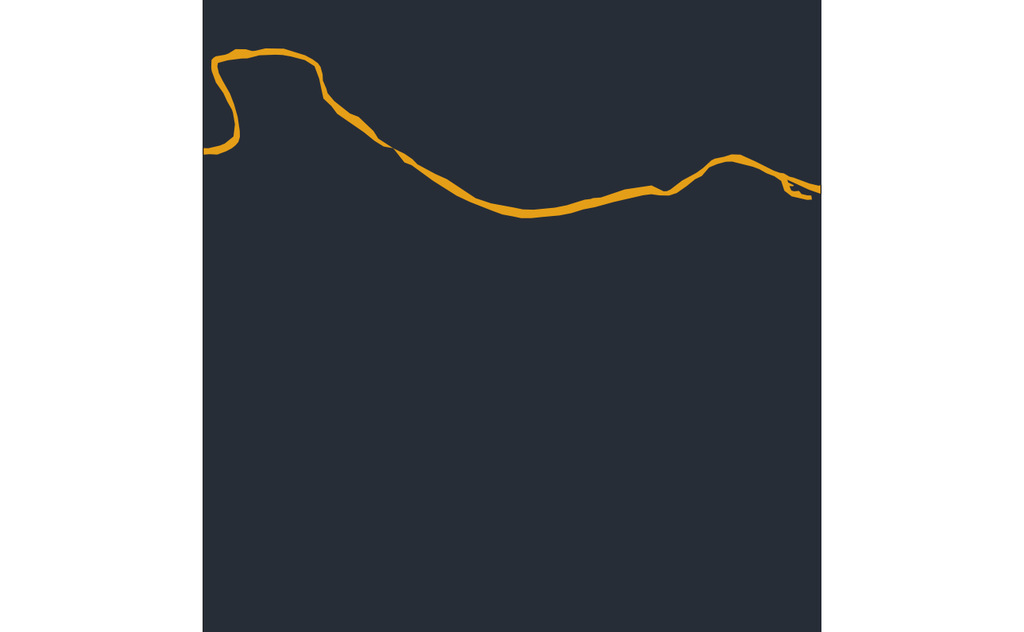

```r
ggplot() +
  geom_sf(data=counties_MI,
          inherit.aes= FALSE,
          lwd=0.0,fill=rgb(0.203,0.234,0.277))+
  coord_sf(xlim = c(min(campus_bbx[1,]), max(campus_bbx[1,])),
         ylim = c(min(campus_bbx[2,]), max(campus_bbx[2,])),
         expand = FALSE)+
  theme(legend.position = F) + theme_void()+
  theme(panel.background=
          element_rect(fill = rgb(0.92,0.679,0.105)))
```

## Putting it all together

We have all of our parts, let’s put them together.

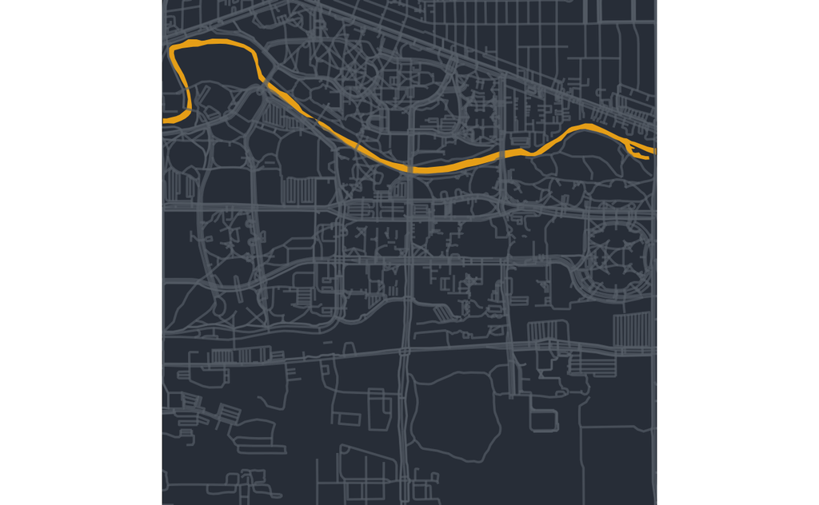

```r
ggplot() +
  geom_sf(data=counties_MI,
          inherit.aes= FALSE,
          lwd=0.0,fill=rgb(0.203,0.234,0.277))+
  geom_sf(data = campus_sidewalks$osm_lines,
          inherit.aes = FALSE,
          color=color_roads,
          size = .4,
          alpha = .65) +
  geom_sf(data = campus_roads$osm_lines,
          inherit.aes = FALSE,
          color=color_roads,
          size = .6,
          alpha = .65) +
  coord_sf(xlim = c(min(campus_bbx[1,]), max(campus_bbx[1,])),
           ylim = c(min(campus_bbx[2,]), max(campus_bbx[2,])),
           expand = FALSE) +
  theme(legend.position = F) + theme_void()+
  theme(panel.background =
          element_rect(fill = rgb(0.92,0.679,0.105)))
```

One last thing, to mark that special place. For my lab group, that is our alternate meeting place, The MSU Dairy Stone.

First get the coordinates from Google Maps.

```r
dairy_store <- data.frame(x = -84.478404, y = 42.724459)
```

Use `geom_point()` to mark it!

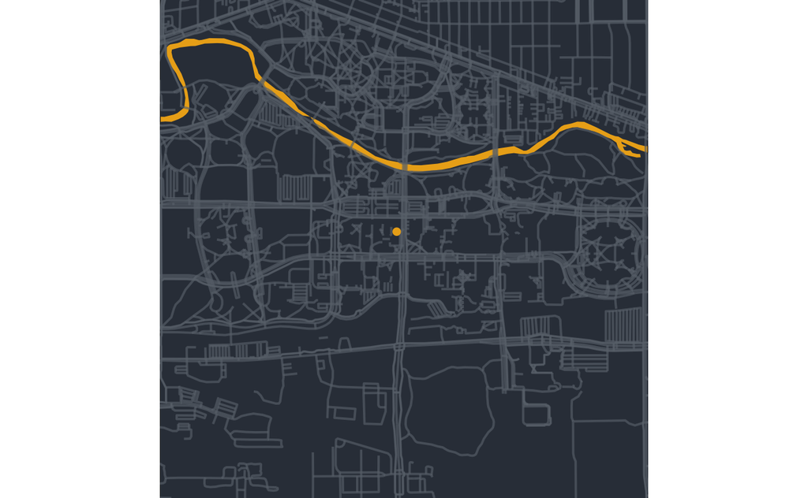

```r
ggplot() +
  geom_sf(data=counties_MI,
          inherit.aes= FALSE,
          lwd=0.0,fill=rgb(0.203,0.234,0.277)) +
  geom_sf(data = campus_sidewalks$osm_lines,
          inherit.aes = FALSE,
          color=color_roads,
          size = .4,
          alpha = .65) +
  geom_sf(data = campus_roads$osm_lines,
          inherit.aes = FALSE,
          color=color_roads,
          size = .6,
          alpha = .65) +
  geom_point(data = dairy_store,
             inherit.aes = FALSE,
             aes(x = x, y = y),
             color = rgb(0.92,0.679,0.105)) +
  coord_sf(xlim = c(min(campus_bbx[1,]), max(campus_bbx[1,])),
           ylim = c(min(campus_bbx[2,]), max(campus_bbx[2,])),
           expand = FALSE) +
  theme(legend.position = F) + theme_void()+
  theme(panel.background =
          element_rect(fill = rgb(0.92,0.679,0.105)))
```

```r
final_map <- ggplot() +
  geom_sf(data=counties_MI,
          inherit.aes= FALSE,
          lwd=0.0,fill=rgb(0.203,0.234,0.277)) +
  geom_sf(data = campus_sidewalks$osm_lines,
          inherit.aes = FALSE,
          color=color_roads,
          size = .4,
          alpha = .65) +
  geom_sf(data = campus_roads$osm_lines,
          inherit.aes = FALSE,
          color=color_roads,
          size = .6,
          alpha = .65) +
  geom_point(data = dairy_store,
             inherit.aes = FALSE,
             aes(x = x, y = y),
             color = rgb(0.92,0.679,0.105)) +
  coord_sf(xlim = c(min(campus_bbx[1,]), max(campus_bbx[1,])),
           ylim = c(min(campus_bbx[2,]), max(campus_bbx[2,])),
           expand = FALSE) +
  theme(legend.position = F) + theme_void()+
  theme(panel.background =
          element_rect(fill = rgb(0.92,0.679,0.105)))
```

## Saving your map

We may want to print our map, add text, or overlap images in other programs such as Google Slides, ImageMagick, or InkScape. To do so, we need to save in high resolution. We will use the `ggsave()` function for this purpose. The width and height will be measured in terms of whatever the `units` argument is set to. In this case I use inches. Also very important is the `dpi` argument. Here it is set to 500, which means the image will be saved with high resolution at 500 dots per inch. This prevents us from printing large, blurry maps! I have not used it here, but `limitsize` may become an argument you need to use if you are trying to save a file larger than 50 inches by 50 inches.

```r
ggsave(final_map,
       filename = "~/personal_campus_map.png",
       width = 24,
       height = 24,
       units = "in",
       dpi = 500)
```

Thanks! If this has interested you, I suggest checking out these other short blog posts: - http://estebanmoro.org/post/2020-10-19-personal-art-map-with-r/ - https://ggplot2tutor.com/tutorials/streetmaps - https://dominicroye.github.io/en/2018/accessing-openstreetmap-data-with-r/